# 第六次作业

3018233061 樊一飞

```python
Needs["HypothesisTesting`"]
```

## 1. 设随机变量X服从B(20, 0.4), 请计算

```python
B = BinomialDistribution[20,.4]
```

(1) $P(X=0)$

```python
PDF[B,0]
```

```
0.0000365616
```

(2)$P(X=1)$

```python
PDF[B,1]
```

```
0.000487488
```

(3)$P(X<2)=P(X\leq 1)$

```python
CDF[B,1]
```

```
0.000524049
```

(4)$P(X\leq 6)$

```python
CDF[B,6]
```

```
0.250011
```

(5)$P(X>10)$ $=1-P(X\leq 10)$

```python
1-CDF[B,10]
```

```
0.127521
```

(6)$P(X\geq 15)=1-P(X<15)=1-P(X\leq 14)$

```python
1-CDF[B,14]
```

```
0.00161152
```

## 2. 给出20个服从均值为0、标准差为3的正态分布的随机数组成的表

```python
nd = NormalDistribution[0,3]
```

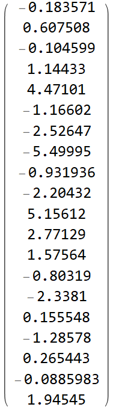

```python
RandomReal[nd,20]//MatrixForm
```

## 3. 给出4个样本值：

{1.1, 2.0, 3.2}, {1.3, 2.2, 3.1}, {1.15, 2.05, 3.35}, {1.22, 2.31, 3.33}

计算样本个数、均值和方差。

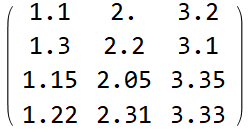

```python
data = {{1.1, 2.0, 3.2}, {1.3, 2.2, 3.1}, {1.15, 2.05, 3.35}, {1.22, 2.31, 3.33}};
data//MatrixForm
```

```python
Length[data]
```

```
4
```

```python
Mean[data]
```

```
{1.1925, 2.14, 3.245}
```

```python
Variance[data]
```

```
{0.00755833, 0.0200667, 0.0137667}
```

## 4.

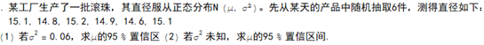

(1)

```python
data = {15.1,14.8,15.2,14.9,14.6,15.1};
data//MatrixForm
```

```python
MeanCI[data,KnowVariance->0.06]
```

[output not shown]

(2)

```python
MeanCI[data]
```

```
{14.713, 15.187}
```

## 5.

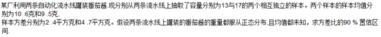

```python
FRatioCI[2.4/4.7,13-1,17-1,ConfidenceLevel->.9]
```

```
{0.210602, 1.32709}
```

## 7.

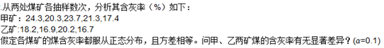

```python
adat = {24.3,20.3,23.7,21.3,17.4};
bdat = {18.2,16.9,20.2,16.7};
```

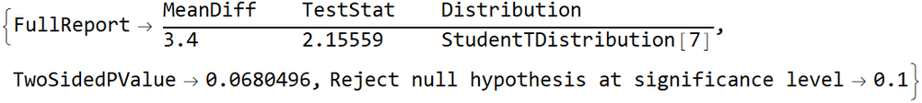

```python
MeanDifferenceTest[adat,bdat,0,EqualVariances->True,SignificanceLevel->0.1,TwoSided->True,FullReport->True]
```

## 8.

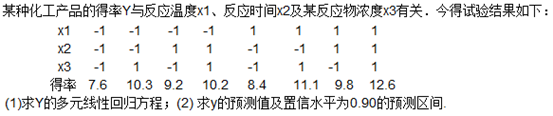

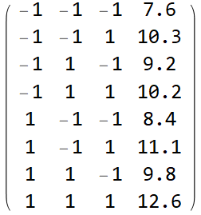

```python
data = {
    {-1,-1,-1,7.6},
    {-1,-1,1,10.3},
    {-1,1,-1,9.2},
    {-1,1,1,10.2},
    {1,-1,-1,8.4},
    {1,-1,1,11.1},
    {1,1,-1,9.8},
    {1,1,1,12.6}
};
data//MatrixForm
```

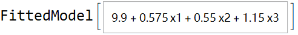

```python
lm = LinearModelFit[data,{1,x1,x2,x3},{x1,x2,x3},ConfidenceLevel->.9]
```

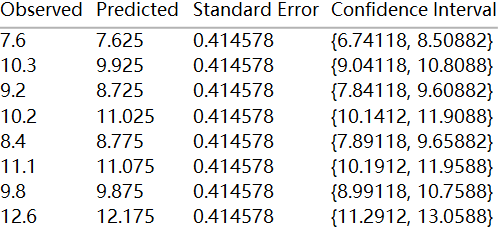

```python
lm["MeanPredictionConfidenceIntervalTable"]
```

## 10. 某地某年高考后随机抽得15名男生、12名女生的物理考试成绩如下:

男生:49 48 47 53 51 43 39 57 56 46 42 44 55 44 40

女生:46 40 47 51 43 36 43 38 48 54 48 34

从这27名学生的成绩能说明这个地区男女生的物理考试成绩不相上下吗?(显著性水平0.05)

```python
male = {49 ,48 ,47 ,53 ,51 ,43 ,39 ,57 ,56 ,46 ,42 ,44 ,55 ,44 ,40}
female = {46 ,40 ,47 ,51 ,43 ,36 ,43 ,38 ,48 ,54 ,48 ,34}
```

```
{49, 48, 47, 53, 51, 43, 39, 57, 56, 46, 42, 44, 55, 44, 40}
```

```
{46, 40, 47, 51, 43, 36, 43, 38, 48, 54, 48, 34}
```

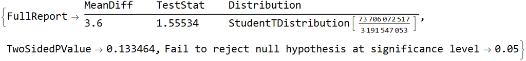

```python
MeanDifferenceTest[male,female,0,SignificanceLevel->.05,TwoSided->True,FullReport->True]
```

接受原假设，男女生的物理考试成绩不相上下

## 11.甲、乙两厂生产同一种电阻

现从甲乙两厂的产品中分别随机抽取12个和10个样品,测得它们的电阻值后,计算出样本方差分别为1.40,4.38, 假设电阻值服从正态分布,在显著性水平0.1下,是否可以认为两厂生产的电阻值的方差相等.

```python
p = FRatioPValue[1.4/4.38,12-1,10-1,TwoSided->True]
p[[2]]>0.1
```

[output not shown]

$PValue<\alpha=0.1$,所以认为不相等

## 12.为比较甲、乙两种安眠药的疗效

将20名患者分成两组,每组10人,若服药后延长的睡眠时间分别服从正态分布,其数据为(单位:小时):

甲:5.5 4.6 4.4 3.4 1.9 1.6 1.1 0.8 0.1,-0.1

乙:3.7 3.4 2.0 2.0 0.8 0.7,0,-0.1,-0.2,-1.6

问在显著性水平0.05下两重要的疗效又无显著差别.

```python
adat = {5.5 ,4.6 ,4.4 ,3.4 ,1.9 ,1.6, 1.1, 0.8, 0.1,-0.1 }
bdat = {3.7, 3.4, 2.0, 2.0, 0.8, 0.7,0,-0.1,-0.2,-1.6}
```

```
{5.5, 4.6, 4.4, 3.4, 1.9, 1.6, 1.1, 0.8, 0.1, -0.1}
```

```
{3.7, 3.4, 2., 2., 0.8, 0.7, 0, -0.1, -0.2, -1.6}
```

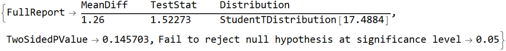

```python
MeanDifferenceTest[adat,bdat,0,SignificanceLevel->0.05,TwoSided->True,FullReport->True]
```

接受原假设，两重要的疗效又无显著差别

## 13. 绘制χ2分布在n分别为1，5，15时的分布密度函数图。

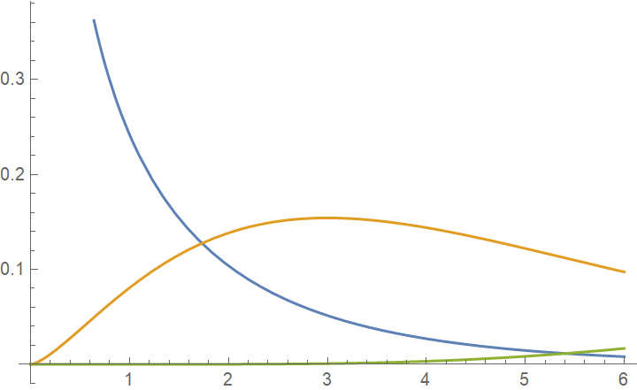

```python
Plot[Evaluate@Table[PDF[ChiSquareDistribution[n],x],{n,{1,5,15}}],{x,0,6]
```

## 14. 一位美国数学家曾经做过一个实验：

在一个人山人海的世界杯赛场上，他随机在某号看台上召唤22个球迷，请他们分别写下自己的出生月和日（如5月1日），结果发现其中两人生日相同。怎么会这么凑巧呢？请利用概率理论并借助于Mathematica来加以解释。

先求22个人生日不同的概率为： $$ \frac{22!\times\binom{365}{22}}{365^{22}} $$

```python
1-22!*Binomial[365,22]/365^22//N
```

```
0.475695
```

## 15. 假设投掷一个均匀硬币只能出现正面和反面两种情况用Mathematica命令来验证投掷出现正面的概率为0.5。

```python
CoinTest[n_]:=RandomInteger[1,n]//Mean//N
```

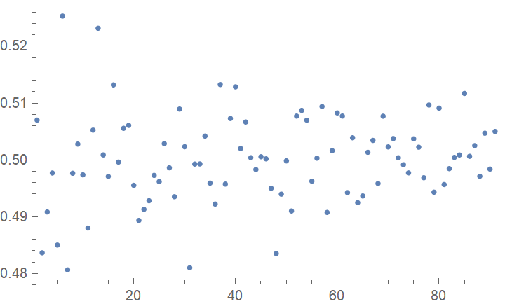

```python
coinResult = Table[CoinTest[n],{n,10^3,10^4,100}];
ListPlot[coinResult]
```

```python
CoinTest[10^4]
```

```
0.5
```